# GBI6 - BIOINFORMÁTICA

### [1 PUNTO] 2.4 Escriba la función `reg_gen_expression`, con el parámetro `gen`. En este caso la función visualizará una gráfica de nube de puntos (geom_point) y una regresión por tipo de “dataset”. La gráfica será de comparación de gen1 con gen2; por ejemplo en el eje “x” `GATA3` y en el eje “y”” `FN1`.

#install.packages(“tidyverse”)

```r
#Para este ejercicio se dbee usar tibble por sus caracteristicas en las dataframe
#Libreria y paque de esta herramienta
#install.packages("tidyverse")
#library(tidyverse)

#Función reg_gen_expression
reg_gen_expression <- function(genN){
  #Se filtra la comparacion de 2 genes
  genN1=genN[1]
  genN2=genN[2]
  filtro2<-filter(df_long,gen==genN1)
  filtro3<-filter(df_long,gen==genN2)
  #Se combinan los dataframe filtrados
  filtroT<-cbind(filtro2,filtro3)
  #Se toma los datos para realizar el nuevo dataframe
  gen_expression<-tibble("dataset"=filtroT[,1],"gen1"=filtroT[,3],"gen2"=filtroT[,6])
  #Se grafica
  regplot<-ggplot(gen_expression,aes(x=gen1,y=gen2,color=dataset))+geom_point()+geom_smooth(method=lm,se=FALSE)
  regplot
}
```

### [0.5 PUNTOS] 2.5. Utilizando la función `lapply()` genera la lista `reg_genplots` con las gráficas para cada par de genes posibles. Recuerde que tiene 7 tipos de genes, se debe tener todas las combinaciones posibles por pares de genes (combinatoria sin repetición).

```r
#Generar la lista.
tipogen<-unique(df_long$gen)
#Combinatoria sin repetición
tipogen_combn<-combn(tipogen,m=2,simplify=FALSE)
reg_genplots<-lapply(tipogen_combn,reg_gen_expression)
```

### [0.5 PUNTOS] 2.6. Guarde en el subdirectorio `result` el onceavo plot de la lista `reg_genplots` con el nombre `regresion11.pdf`. La definición de a figura debe ser de 300dpi.

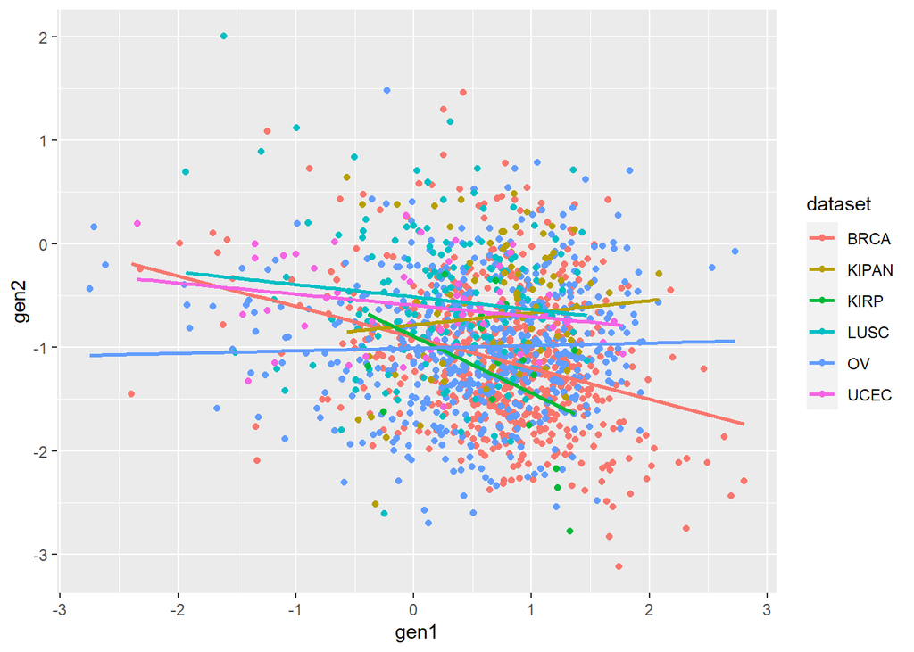

```r
#Guardar el onceavo plot.
reg_genplots[[11]]
```

```r
ggsave("results/regresion11.pdf",dpi = 300)
```

```r
#Se nombre una nueva variable para resolver el siguiente literal
reg11=reg_genplots[[3]]
```

### [1 PUNTO] 2.7. Interprete los resultados de las figuras `boxplot3.png` y `regresion11.pdf`.

```latex
BOXPLOT
El tercer boxplot, muestra los genes presentes en la datafrane, donde los siguientes genes tienen mayor distribucion
en los sigientes quintiles: GATA3 en Q1 y Q2, PTEN en Q4, XBP1, ESR1 y GAPDH en Q3, y MUC1 en conjutno con FN1 poseen
una distribucion mas equilibrada en todos los quintiles. Igualemente, se puede decir que esta distribucion de puntos
en la mayoria de los casos es asimetrico y con valores atipicos, no teniendo una distriubucion normal clara.


REGRESION
La regresion 11, posee una gran cantidad de puntos, donde destacan los provenientes de los canceres BRCA y OV
(previamente mencionados en la descripcion de la tabla). Por lo tanto, su nube de puntos se representa esta
concentracion de los cancecres presentes en estos 2 genes.
```

## 3. CONTROL DE LA VERSIÓN [1 PUNTO]. Se verficará en ell repositorio de GitHub.